# Mental Rotation Task in Psychopy

### Adding some instructions

Before we look at the output file, let’s make this experiment a bit more user friendly and complete. Let’s add some instructions before the trials start. This will give us the opportunity to add a new routine and review the loops.

In the builder window, let’s add a new routine by pressing *Insert Routine* in the *flow* panel. Click on *(new)* and then name the routine *instructions*.

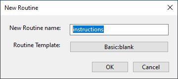

creating a routine instruction

Press OK and you will see that a dot appears on the *flow* arrow. As for the loop, you use your mouse to select where in the flow you would like to add the new routine. Here we click before the trial routine, *outside the loop!*. Think about what would happen if you add the new routine inside the loop.

[figure not shown]

creating a routine instruction flow view

At the moment, this is a empty routine. We need to populate it with some instructions. The following is my personal approach, but other possibilities exist. As you will see, I exploit the loops to present different text slides without having to create multiple components. Let’s see how it is done.

Firstly, we need to create a brand new condition csv file. Open *OpenOffice Calc* or *Excel* and create a new spreadsheet. Here we need only one parameter and we will call it *intro_text*. The idea here is to present the instructions as self-paced trials, so to have the text nicely spread and not crowded into one single slide. Thus, we will divide the instructions into different rows of our new spreadsheet. For instance, here we will have four rows containing the following text:

[output not shown]

[figure not shown]

Intro slide condition file

Save this file in the same directory as the condition file. Now head back to the builder window and add a loop around the instructions routine. Called this *loop_intro*, set the *nReps* parameter to 1 and, most importantly, *set the loopType paramter to sequential* sot that Psychopy will go through the rows of the instruction csv file sequentially, from the first one to the fourth one. In the *Conditions* field, navigate to the just created csv file and select it.

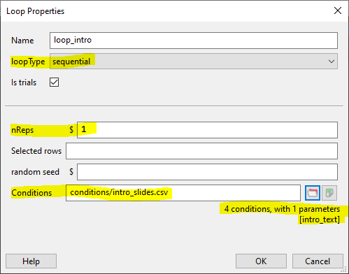

setting up a loop for the instruction slides

Sweet, now we need to set up something to display our instructions. This is simply a *Text* component. So, go ahead and add a new text component to the instructions routine. Call this component *intro_slides* and set this to start at time 0.0. Here, we want the text to be presented for as long as the participant wants. To do this, we need to leave the *Duration* field empty. In the text field we need to tell Psychopy to use what we wrote in the csv file. Do you remember how we tell Psychopy to use a variable created in a file? Yup, by using the ***$*** symbol followed by the variable name in our file. In this case, In the *Text* field we write *$intro_text* and then we set this to update every repeat.

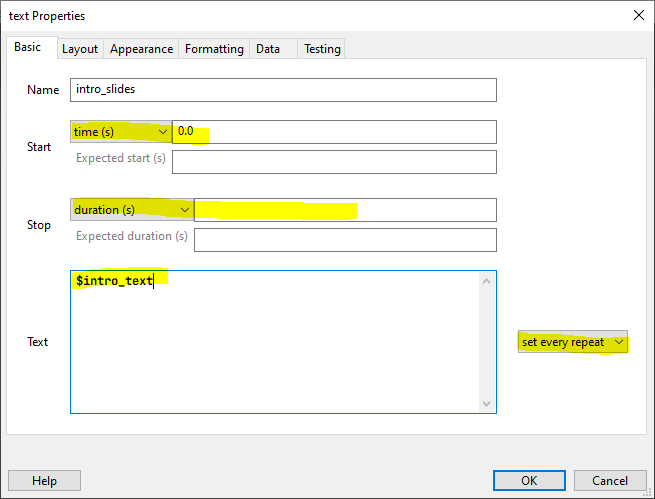

adding a text component to show the instruction slides

I leave to you changing the font size and other options so you can play around with those. Remember what units we are using!

Finally, we need a way for the participant to move to one slide to the next one. We will tell the participant to press the space bar to do so. So, let’s add a *Keyboard* component, and set it to accept only the spacebar and to terminate the current trial (slide) when that key is pressed.

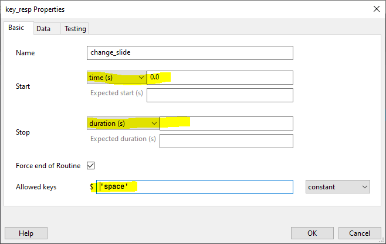

adding a keyboard component to the instruction slides

Note that the duration is infinite to match the infinite duration of the *intro_slide* component. This means that Psychopy just waits for the participant to press space.

### Test yourself

Fantastic! We have got a working experiment! This would work fine but it could be improved. Here I leave you with a list of things you could try to do do by yourself. Some of these exercises will require some googleing, so don’t worry if you get stuck. I have left a complete builder file on github so that you can download it and check my solution.

1. Add a “Press space bar to continue” text underneath each instruction slide
2. Add a thank you slide at the end of the experiment
3. Make the experiment to run 100 trials in a random order (each trial is presented twice during a session)
4. Add a routine (add a countdown from 5 to 0) between the instructions and the trial routine ([hint](https://discourse.psychopy.org/t/digital-15s-countdown-on-each-screen/10712))
5. Add a square box around each of the two letters. Make it white. (hint: i there a way to set a colour opacity? If not, what colour is the background? Remember that the order of the components matter!)

### Using code to extend the experiment

This is section is a bit more advanced, but it will show how we can use python to expand our experiment. As an example here, we will add a way to modify the length of each trial without having to change each component duration every time. Sounds good? Let’s begin!

Go over the *trial* routine. Here we need to add a new component. Look inside the *Custom* menu on the *Components* panel. Click on *Code*. This component allows you to add custom python code inside your experiment at different moments as required. Once you click on the component a new window will appear. As this is a component it needs a unique name, let’s say *my_code*. You can also see 6 tabs:

1. *Before Experiment*: Here we can add all the code that should be run before everything else in the experiment. Usually we use this tab only when we need to load specific [Python modules](https://www.w3schools.com/python/python_modules.asp) that do not ship with Psychopy.
2. *Begin Experiment*: Here we add code that needs to be run at the beginning of the experiment. For instance, we might want to define some variables that need to be used throughout the experiment, to multiple routines.
3. *Begin Routine*: The code added here will be run every time the current routine (where the code component is added) starts. We can add code here to update specific parameters every time a routine starts again
4. *Each Frame*: The code added in this tab will be evaluated each time a new frame is drawn on your screen. This offers us a powerful way to manipulate stimuli, but we need to pay attention at what code we evaluate here. If the code requires too much time to be executed, it might not be evaluated exactly every one frame, which could potentially create problems in our timing.
5. *End Routine*: The code here will be evaluated just before a routine is going to end
6. *End Experiment*: the code added here is evaluated at the end of the experiment.

To accomplish our task we need to first define a variable that stores the time, in seconds, our trial should last. In the *Begin Experiment* tab, add the following line:

`trial_time = 6`

This creates a variable called *trial_time* and we set it to be 6. We will use this variable to set the time of every component in the trial routine to 6 seconds. Note that we have used the *Begin Experiment* because we want this value to not change during the experiment and to be always available.

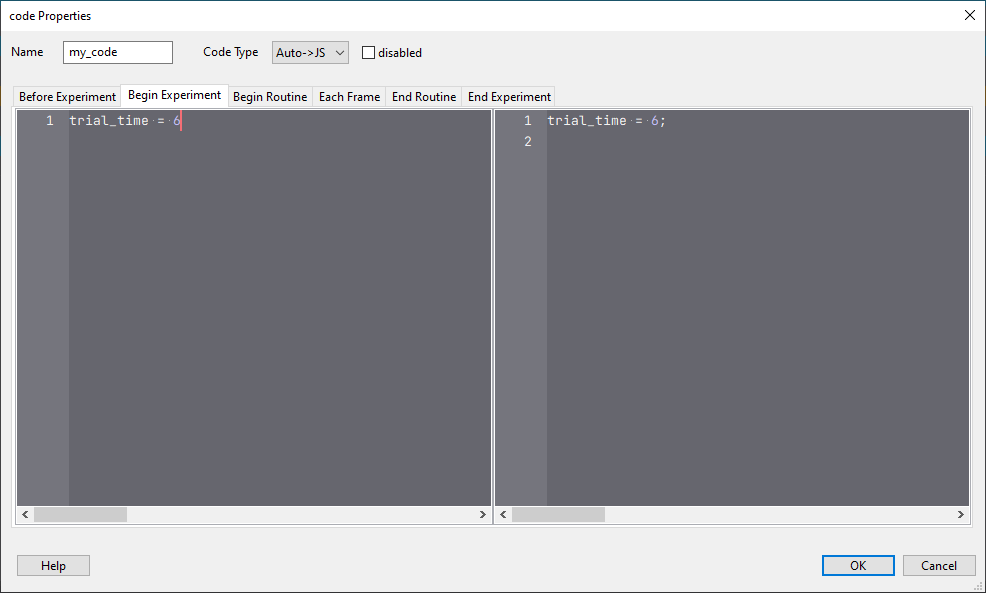

Adding a code snippet to the experiment

Press OK. Now, as we are using the code to define a variable we will use in other components, we want this code component to be evaluated first. So, right click on it and select *move to top*. This might not be always necessary, but in my experience this is usually the case. Ok, now we need to use the variable we just created. To do this, open the *target* component properties first. The *Duration* field is currently set to 0. Replace this with *trial_time* (the name of our newly create variable that stores the duration time we want).

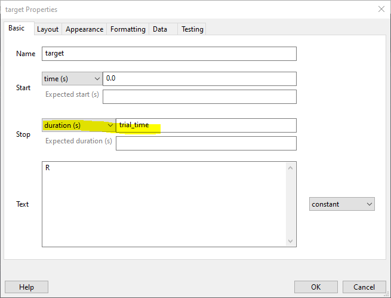

Adding a code snippet to the experiment

Some of you might wonder why we do not need to use the *$* sign. Well, this because the code components add the lines of codes we define directly into the python script that Psychopy runs to present our experiment. Thus, here is like if we have added a variable towards the beginning of the experiment, before the trial routine is run. Consequently, when we run the experiment, this variable is created and it’s always available.

Amazing, now let’s replace the current *Duration* value of every component in the trial routine with the *trial_time* variable. Now, if you run the experiment, each trial will last 6 seconds (if no keys are pressed). Do you want to have a trial to last 10 seconds, no problems! Go into your code component and change the value of the *trial_time* variable. With only one change, we are modifying the multiple components.

### A bit more of code components

Alright, the previous was a simple example. However, we can use code components to do more intricate things. For instance, we could change the letter presented in each trial in a randomized way. Specifically, let’s modify the experiment so that in each trial a random letter between A, B, R, and K is presented (rather than only Rs).

*NOTE: here we will use some functions from the module Numpy and some more advanced notions. I won’t explain all the details in this tutorial, as it is already long. These are covered in class though*

The first thing we need to do is to create a list of possible letters to choose from. Open the *my_code* component and in the *Begin Experiment* create a variable called *possible_letters* containing a list of the letters we would like to present

`possible_letters = ["A", "B", "R", "K"]`

Note that we need to define the letters a string (““). Amazing, this variable will be the place from where we will pick a letter for each trial.

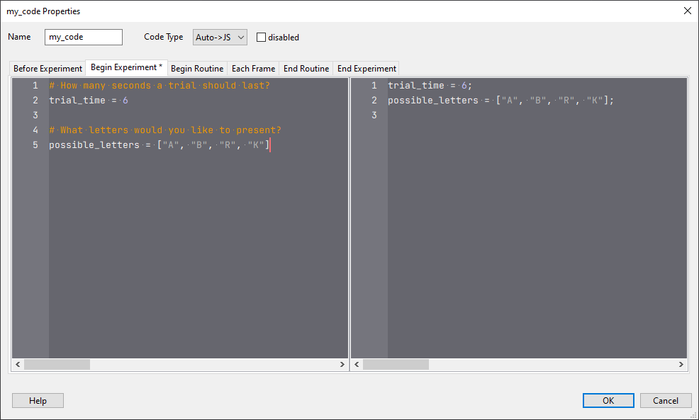

Adding a list of letters to draw from in each trial

Now move to the *Begin Routine* tab. Every time a trial starts (the trial routine begins) we need to select a letter to present among the ones we defined before. To do so, we will randomly pick from *possible_letters*. Thus, add the code:

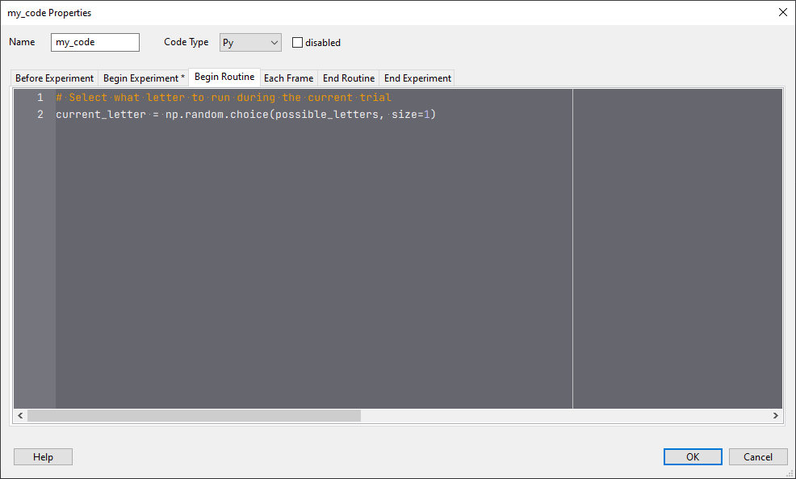

Selecting a letter to present during the current trial

Sweet, the coding part is done! What we need to do is now to set the text to be presented as the *current_letter* variable. To do so, open the *target* component *Properties* and replace the *R* in the *Text* field with *$current_letter* - our variable containing the letter randomly selected. We also need to set this variable to update every repeat. Note the use of the dolalar sign to tell Python that we are referring to a variable that is updated every time the routine begins.

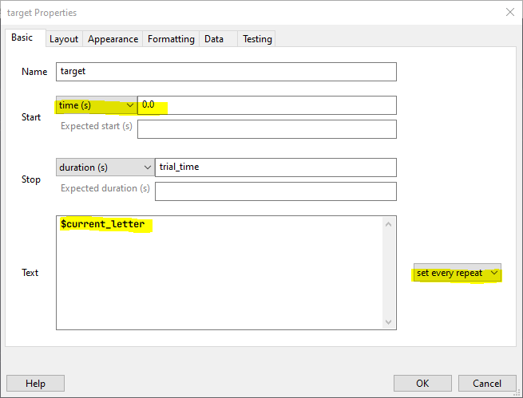

updating the letter to be displayed

Repeate the same for the *letter* component. Now, when we run the experiment, the letter is changed for every trial.

[figure not shown]

[figure not shown]